# Sprawozdanie4

Łukasz Maczek, Marta Kreis

2025-11-03

# Potrzebne biblioteki

```r
library(rpart)
library(rattle)
library(caret)
library(vip)
library(VIM)
library(randomForest)
library(dplyr)
library(ggplot2)
library(tidyr)
```

# Zbiory danych

## Stroke

Na początku zadania wczytano plik `Stroke`, który zawiera dane dotyczące pacjentów, u których miał miejsce udar lub nie. Zbiór składa się z 11 zmiennych:

- Gender (płeć) - zmienna kategoryczna
- Age (wiek) - zmienna liczbowa
- Hypertension (nadciśnienie) - zmienna binarna (1 gdy nadciśnienie występuje)
- Heart_disease (choroba serca) - zmienna binarna (1 gdy choroba serca występuje)
- Ever_married (Czy osoba była kiedyś w związku małżeńskim) - zmienna kategoryczna
- Work_type (Prywatna, Rządowa, Samozatrudnienie, Bezrobotny, Dziecko)
- Residence_type (Miejsce zamieszkania) - zmienna kategoryczna
- Avg_glucose_level (średni poziom glukozy) - zmienna liczbowa
- Bmi - zmienna liczbowa
- Smoking_status (Kiedyś palił, Nadal pali, Nigdy nie palił, Nieznane) - zmienna kategoryczna
- Stroke (udar) - zmienna binarna (1 gdy wystąpił udar)

# Przygotowanie danych

```r
dane_stroke = read.csv2("zaj3_Stroke.csv", dec = ".")

dane_stroke$work_type = as.factor(dane_stroke$work_type)
dane_stroke$smoking_status = as.factor(dane_stroke$smoking_status)
dane_stroke$gender = as.factor(dane_stroke$gender)
dane_stroke$age = as.numeric(dane_stroke$age)
dane_stroke$avg_glucose_level = as.numeric(gsub(",", ".",dane_stroke$avg_glucose_level))
dane_stroke$bmi = as.numeric(gsub(",", ".",dane_stroke$bmi))
dane_stroke$hypertension = as.factor(dane_stroke$hypertension)
dane_stroke$heart_disease = as.factor(dane_stroke$heart_disease)
dane_stroke$ever_married = as.factor(dane_stroke$ever_married)
dane_stroke$Residence_type = as.factor(dane_stroke$Residence_type)
dane_stroke$stroke = as.factor(dane_stroke$stroke)

#braki danych uzupełnione knn
set.seed(123)
dane_stroke_final = kNN(dane_stroke, k = 5)
```

[output not shown]

```r
summary(dane_stroke_final)
```

```
##     gender         age        hypertension heart_disease ever_married
##  Female:239   Min.   : 2.00   0:324        0:346         No : 98
##  Male  :161   1st Qu.:42.00   1: 76        1: 54         Yes:302
##               Median :59.00
##               Mean   :55.54
##               3rd Qu.:75.00
##               Max.   :82.00
##          work_type   Residence_type avg_glucose_level      bmi
##  children     : 27   Rural:192      Min.   : 55.42    Min.   :14.20
##  Govt_job     : 65   Urban:208      1st Qu.: 83.03    1st Qu.:25.68
##  Never_worked :  1                  Median :102.31    Median :29.30
##  Private      :222                  Mean   :121.91    Mean   :30.39
##  Self-employed: 85                  3rd Qu.:150.82    3rd Qu.:33.70
##                                     Max.   :271.74    Max.   :58.10
##          smoking_status stroke  gender_imp       age_imp
##  formerly smoked: 86    0:200   Mode :logical   Mode :logical
##  never smoked   :152    1:200   FALSE:400       FALSE:395
##  smokes         : 66                            TRUE :5
##  Unknown        : 96
##
##
##  hypertension_imp heart_disease_imp ever_married_imp work_type_imp
##  Mode :logical    Mode :logical     Mode :logical    Mode :logical
##  FALSE:400        FALSE:376         FALSE:400        FALSE:353
##                   TRUE :24                           TRUE :47
##
##
##
##  Residence_type_imp avg_glucose_level_imp  bmi_imp        smoking_status_imp
##  Mode :logical      Mode :logical         Mode :logical   Mode :logical
##  FALSE:400          FALSE:359             FALSE:363       FALSE:400
##                     TRUE :41              TRUE :37
##
##
##
##  stroke_imp
##  Mode :logical
##  FALSE:400
##
##
##
##
```

Zbiór jest zbalansowany (po 50% wyników pozytywnych i negatywnych dla stroke)

```r
summary(dane_stroke_final$stroke)
```

```
##   0   1
## 200 200
```

# Zadanie 2

## Model drzewa decyzyjnego

```r
set.seed(123)
index = sample(nrow(dane_stroke_final), size = 0.2*nrow(dane_stroke_final), replace = F)
testowy = dane_stroke_final[index,]
uczacy = dane_stroke_final[-index,]
model = rpart(stroke ~.,
              data = uczacy,
              method = "class")
model
```

```
## n= 320
##
## node), split, n, loss, yval, (yprob)
##       * denotes terminal node
##
##  1) root 320 157 1 (0.49062500 0.50937500)
##    2) age< 48.5 103  10 0 (0.90291262 0.09708738) *
##    3) age>=48.5 217  64 1 (0.29493088 0.70506912)
##      6) age< 60.5 63  31 0 (0.50793651 0.49206349)
##       12) avg_glucose_level< 82.28 13   2 0 (0.84615385 0.15384615) *
##       13) avg_glucose_level>=82.28 50  21 1 (0.42000000 0.58000000)
##         26) work_type=Govt_job,Self-employed 18   7 0 (0.61111111 0.38888889) *
##         27) work_type=Private 32  10 1 (0.31250000 0.68750000)
##           54) bmi>=40.1 8   3 0 (0.62500000 0.37500000) *
##           55) bmi< 40.1 24   5 1 (0.20833333 0.79166667) *
##      7) age>=60.5 154  32 1 (0.20779221 0.79220779) *
```

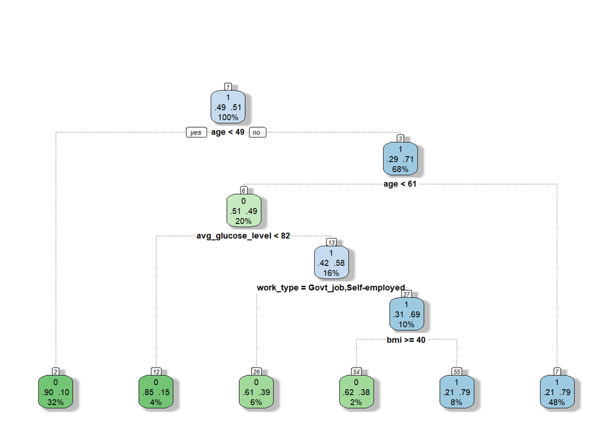

```r
#Wykres
fancyRpartPlot(model, sub = NULL)
```

```r
#predykcja na zbiorze uczącym i testowym
y_pred_stroke = predict(model, newdata = uczacy, type = "class")
y_pred_test = predict(model, newdata = testowy, type = "class")
#uczący
confusionMatrix(y_pred_stroke, uczacy$stroke, positive = "1")
```

```
## Confusion Matrix and Statistics
##
##           Reference
## Prediction   0   1
##          0 120  22
##          1  37 141
##
##                Accuracy : 0.8156
##                  95% CI : (0.7687, 0.8566)
##     No Information Rate : 0.5094
##     P-Value [Acc > NIR] : < 2e-16
##
##                   Kappa : 0.6305
##
##  Mcnemar's Test P-Value : 0.06836
##
##             Sensitivity : 0.8650
##             Specificity : 0.7643
##          Pos Pred Value : 0.7921
##          Neg Pred Value : 0.8451
##              Prevalence : 0.5094
##          Detection Rate : 0.4406
##    Detection Prevalence : 0.5563
##       Balanced Accuracy : 0.8147
##
##        'Positive' Class : 1
##
```

```r
#testowy
confusionMatrix(y_pred_test, testowy$stroke, positive = "1")
```

```
## Confusion Matrix and Statistics
##
##           Reference
## Prediction  0  1
##          0 29  8
##          1 14 29
##
##                Accuracy : 0.725
##                  95% CI : (0.6138, 0.819)
##     No Information Rate : 0.5375
##     P-Value [Acc > NIR] : 0.0004578
##
##                   Kappa : 0.4531
##
##  Mcnemar's Test P-Value : 0.2864220
##
##             Sensitivity : 0.7838
##             Specificity : 0.6744
##          Pos Pred Value : 0.6744
##          Neg Pred Value : 0.7838
##              Prevalence : 0.4625
##          Detection Rate : 0.3625
##    Detection Prevalence : 0.5375
##       Balanced Accuracy : 0.7291
##
##        'Positive' Class : 1
##
```

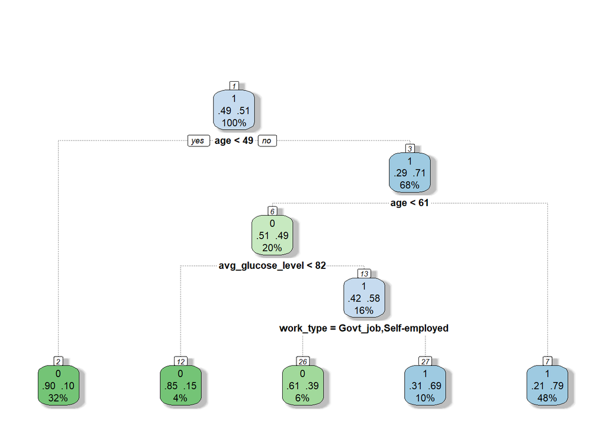

```r
#Model ze zmienioną maksymalną głębokością
model2 = rpart(stroke ~.,
               data = uczacy,
               method = "class",
               control = rpart.control(maxdepth = 4))
fancyRpartPlot(model2, sub = NULL)
```

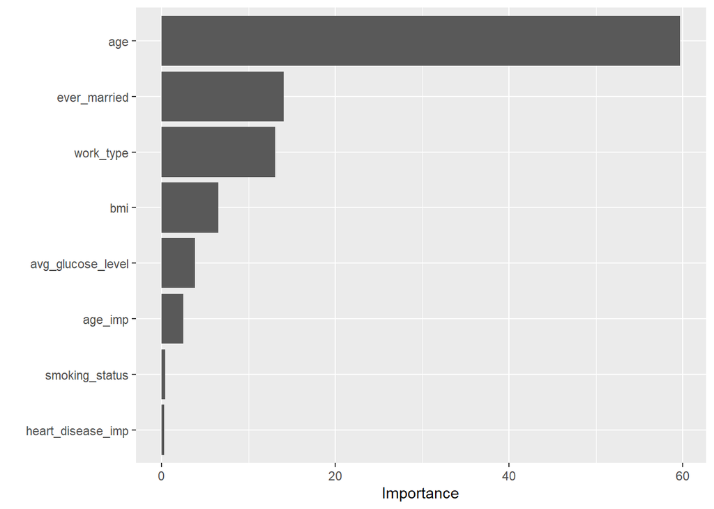

```r
#Ważność zmiennych
vip(model2)
```

```r
#pakiet caret i drzewa decyzyjne
model3 = caret::train(stroke ~.,
                      data = uczacy,
                      method = "rpart",
                      tuneGrid = expand.grid(cp = seq(0.02, 0.2, 0.02)))
```

## 2a) Wpływ przycięcia drzewa na wyniki

```r
set.seed(123)
# Drzewo bez ograniczenia
model_full <- rpart(stroke ~ ., data = uczacy, method = "class")

# Drzewo przycięte
model_pruned <- rpart(stroke ~ ., data = uczacy, method = "class",
                      control = rpart.control(maxdepth = 4))

# Predykcje
pred_train_full <- predict(model_full, newdata = uczacy, type = "class")
pred_test_full <- predict(model_full, newdata = testowy, type = "class")
pred_train_pruned <- predict(model_pruned, newdata = uczacy, type = "class")
pred_test_pruned <- predict(model_pruned, newdata = testowy, type = "class")

# Macierze pomyłek
cm_train_full <- confusionMatrix(pred_train_full, uczacy$stroke, positive = "1")
cm_test_full <- confusionMatrix(pred_test_full, testowy$stroke, positive = "1")
cm_train_pruned <- confusionMatrix(pred_train_pruned, uczacy$stroke, positive = "1")
cm_test_pruned <- confusionMatrix(pred_test_pruned, testowy$stroke, positive = "1")

cm_test_full
```

```
## Confusion Matrix and Statistics
##
##           Reference
## Prediction  0  1
##          0 29  8
##          1 14 29
##
##                Accuracy : 0.725
##                  95% CI : (0.6138, 0.819)
##     No Information Rate : 0.5375
##     P-Value [Acc > NIR] : 0.0004578
##
##                   Kappa : 0.4531
##
##  Mcnemar's Test P-Value : 0.2864220
##
##             Sensitivity : 0.7838
##             Specificity : 0.6744
##          Pos Pred Value : 0.6744
##          Neg Pred Value : 0.7838
##              Prevalence : 0.4625
##          Detection Rate : 0.3625
##    Detection Prevalence : 0.5375
##       Balanced Accuracy : 0.7291
##
##        'Positive' Class : 1
##
```

```r
cm_test_pruned
```

```
## Confusion Matrix and Statistics
##
##           Reference
## Prediction  0  1
##          0 29  8
##          1 14 29
##
##                Accuracy : 0.725
##                  95% CI : (0.6138, 0.819)
##     No Information Rate : 0.5375
##     P-Value [Acc > NIR] : 0.0004578
##
##                   Kappa : 0.4531
##
##  Mcnemar's Test P-Value : 0.2864220
##
##             Sensitivity : 0.7838
##             Specificity : 0.6744
##          Pos Pred Value : 0.6744
##          Neg Pred Value : 0.7838
##              Prevalence : 0.4625
##          Detection Rate : 0.3625
##    Detection Prevalence : 0.5375
##       Balanced Accuracy : 0.7291
##
##        'Positive' Class : 1
##
```

## 2b) Wpływ reguły klasyfikacyjnej (indeks Giniego vs entropia)

Porównano dwie reguły podziału: **indeks Giniego** i **entropię**.

```r
set.seed(123)
model_gini <- rpart(stroke ~ ., data = uczacy, method = "class",
                    parms = list(split = "gini"),
                    control = rpart.control(cp = 0.01, maxdepth = 4))

model_entropy <- rpart(stroke ~ ., data = uczacy, method = "class",
                       parms = list(split = "information"),
                       control = rpart.control(cp = 0.01, maxdepth = 4))

pred_gini <- predict(model_gini, newdata = testowy, type = "class")
pred_entropy <- predict(model_entropy, newdata = testowy, type = "class")

cm_gini <- confusionMatrix(pred_gini, testowy$stroke, positive = "1")
cm_entropy <- confusionMatrix(pred_entropy, testowy$stroke, positive = "1")

cm_gini
```

```
## Confusion Matrix and Statistics
##
##           Reference
## Prediction  0  1
##          0 29  8
##          1 14 29
##
##                Accuracy : 0.725
##                  95% CI : (0.6138, 0.819)
##     No Information Rate : 0.5375
##     P-Value [Acc > NIR] : 0.0004578
##
##                   Kappa : 0.4531
##
##  Mcnemar's Test P-Value : 0.2864220
##
##             Sensitivity : 0.7838
##             Specificity : 0.6744
##          Pos Pred Value : 0.6744
##          Neg Pred Value : 0.7838
##              Prevalence : 0.4625
##          Detection Rate : 0.3625
##    Detection Prevalence : 0.5375
##       Balanced Accuracy : 0.7291
##
##        'Positive' Class : 1
##
```

```r
cm_entropy
```

```
## Confusion Matrix and Statistics
##
##           Reference
## Prediction  0  1
##          0 28  8
##          1 15 29
##
##                Accuracy : 0.7125
##                  95% CI : (0.6005, 0.8082)
##     No Information Rate : 0.5375
##     P-Value [Acc > NIR] : 0.001038
##
##                   Kappa : 0.4293
##
##  Mcnemar's Test P-Value : 0.210903
##
##             Sensitivity : 0.7838
##             Specificity : 0.6512
##          Pos Pred Value : 0.6591
##          Neg Pred Value : 0.7778
##              Prevalence : 0.4625
##          Detection Rate : 0.3625
##    Detection Prevalence : 0.5500
##       Balanced Accuracy : 0.7175
##
##        'Positive' Class : 1
##
```

## Interpretacja wyników drzewa decyzyjnego

Model drzewa decyzyjnego osiągnął dokładność na poziomie około **72,5%** na zbiorze testowym, przy czułości **78%** i specyficzności **67%**. Oznacza to, że model dobrze wykrywa przypadki udaru, ale nieco gorzej rozpoznaje osoby zdrowe.

Porównując różne reguły podziału — **indeks Giniego** i **entropię** — zauważono niewielkie różnice w wynikach. Modele zbudowane na obu kryteriach dają podobną skuteczność, dlatego można pozostać przy indeksie Giniego jako bardziej standardowym podejściu.

# Zadanie 3

## Zastosowanie Baggingu

```r
p = ncol(uczacy) - 1  # liczba predyktorów (zakładamy, że stroke jest jedną z kolumn)
predictors = setdiff(names(uczacy), "stroke")

ntree_list = c(10, 50, 100, 200, 500)
# sampsize jako ułamek lub liczba — użyjemy proporcji względem nrow(uczacy)
sampsize_prop = c(0.5, 0.7, 0.9, 1.0)

# Metryki dla danej predykcji
calc_metrics = function(true, pred, positive_level = "1") {
  cm = caret::confusionMatrix(pred, true, positive = positive_level)
  out = c(Accuracy = as.numeric(cm$overall["Accuracy"]),
          Sensitivity = as.numeric(cm$byClass["Sensitivity"]),
          Specificity = as.numeric(cm$byClass["Specificity"]))
  return(out)
}

set.seed(123)
results = data.frame()
for(nt in ntree_list) {
  for(sp in sampsize_prop) {
    cat("Trenuję: ntree =", nt, "sampsize_prop =", sp, "\n")
    sampsize_n = floor(nrow(uczacy) * sp)
    if(sampsize_n < 1) next

    rf = randomForest(
      formula = stroke ~ .,
      data = uczacy,
      ntree = nt,
      mtry = p,
      sampsize = sampsize_n,
      replace = TRUE
    )

    # Predykcje - na zbiorze uczącym i testowym
    pred_train = predict(rf, newdata = uczacy, type = "response")
    pred_test = predict(rf, newdata = testowy, type = "response")

    # Metryki
    met_train = calc_metrics(uczacy$stroke, pred_train, positive_level = "1")
    met_test  = calc_metrics(testowy$stroke, pred_test, positive_level = "1")

    # Zapisywanie wyniku
    results = rbind(results, data.frame(
      ntree = nt,
      sampsize_prop = sp,
      sampsize_n = sampsize_n,
      Accuracy_train = met_train["Accuracy"],
      Sensitivity_train = met_train["Sensitivity"],
      Specificity_train = met_train["Specificity"],
      Accuracy_test  = met_test["Accuracy"],
      Sensitivity_test = met_test["Sensitivity"],
      Specificity_test = met_test["Specificity"]
    ))
  }
}
```

```
## Trenuję: ntree = 10 sampsize_prop = 0.5
## Trenuję: ntree = 10 sampsize_prop = 0.7
## Trenuję: ntree = 10 sampsize_prop = 0.9
## Trenuję: ntree = 10 sampsize_prop = 1
## Trenuję: ntree = 50 sampsize_prop = 0.5
## Trenuję: ntree = 50 sampsize_prop = 0.7
## Trenuję: ntree = 50 sampsize_prop = 0.9
## Trenuję: ntree = 50 sampsize_prop = 1
## Trenuję: ntree = 100 sampsize_prop = 0.5
## Trenuję: ntree = 100 sampsize_prop = 0.7
## Trenuję: ntree = 100 sampsize_prop = 0.9
## Trenuję: ntree = 100 sampsize_prop = 1
## Trenuję: ntree = 200 sampsize_prop = 0.5
## Trenuję: ntree = 200 sampsize_prop = 0.7
## Trenuję: ntree = 200 sampsize_prop = 0.9
## Trenuję: ntree = 200 sampsize_prop = 1
## Trenuję: ntree = 500 sampsize_prop = 0.5
## Trenuję: ntree = 500 sampsize_prop = 0.7
## Trenuję: ntree = 500 sampsize_prop = 0.9
## Trenuję: ntree = 500 sampsize_prop = 1
```

```r
results = results %>% arrange(ntree, sampsize_prop)
print(results)
```

```
##            ntree sampsize_prop sampsize_n Accuracy_train Sensitivity_train
## Accuracy      10           0.5        160       0.903125         0.9263804
## Accuracy1     10           0.7        224       0.953125         0.9693252
## Accuracy2     10           0.9        288       0.984375         0.9938650
## Accuracy3     10           1.0        320       0.984375         0.9815951
## Accuracy4     50           0.5        160       0.950000         0.9570552
## Accuracy5     50           0.7        224       0.987500         0.9938650
## Accuracy6     50           0.9        288       0.996875         1.0000000
## Accuracy7     50           1.0        320       1.000000         1.0000000
## Accuracy8    100           0.5        160       0.962500         0.9815951
## Accuracy9    100           0.7        224       0.993750         1.0000000
## Accuracy10   100           0.9        288       1.000000         1.0000000
## Accuracy11   100           1.0        320       1.000000         1.0000000
## Accuracy12   200           0.5        160       0.971875         0.9815951
## Accuracy13   200           0.7        224       0.996875         0.9938650
## Accuracy14   200           0.9        288       1.000000         1.0000000
## Accuracy15   200           1.0        320       1.000000         1.0000000
## Accuracy16   500           0.5        160       0.956250         0.9754601
## Accuracy17   500           0.7        224       1.000000         1.0000000
## Accuracy18   500           0.9        288       1.000000         1.0000000
## Accuracy19   500           1.0        320       1.000000         1.0000000
##            Specificity_train Accuracy_test Sensitivity_test Specificity_test
## Accuracy           0.8789809        0.7500        0.8108108        0.6976744
## Accuracy1          0.9363057        0.7250        0.7297297        0.7209302
## Accuracy2          0.9745223        0.7125        0.7297297        0.6976744
## Accuracy3          0.9872611        0.7250        0.7027027        0.7441860
## Accuracy4          0.9426752        0.7125        0.7837838        0.6511628
## Accuracy5          0.9808917        0.7250        0.7567568        0.6976744
## Accuracy6          0.9936306        0.7250        0.7297297        0.7209302
## Accuracy7          1.0000000        0.7125        0.7837838        0.6511628
## Accuracy8          0.9426752        0.7375        0.8108108        0.6744186
## Accuracy9          0.9872611        0.7000        0.7567568        0.6511628
## Accuracy10         1.0000000        0.7250        0.7837838        0.6744186
## Accuracy11         1.0000000        0.7125        0.7837838        0.6511628
## Accuracy12         0.9617834        0.7250        0.7837838        0.6744186
## Accuracy13         1.0000000        0.7375        0.8108108        0.6744186
## Accuracy14         1.0000000        0.7125        0.7567568        0.6744186
## Accuracy15         1.0000000        0.7250        0.7837838        0.6744186
## Accuracy16         0.9363057        0.7125        0.7837838        0.6511628
## Accuracy17         1.0000000        0.7250        0.7837838        0.6744186
## Accuracy18         1.0000000        0.7250        0.7567568        0.6976744
## Accuracy19         1.0000000        0.7375        0.7837838        0.6976744
```

## Jak liczba drzew i rozmiar próby wpływa na metryki

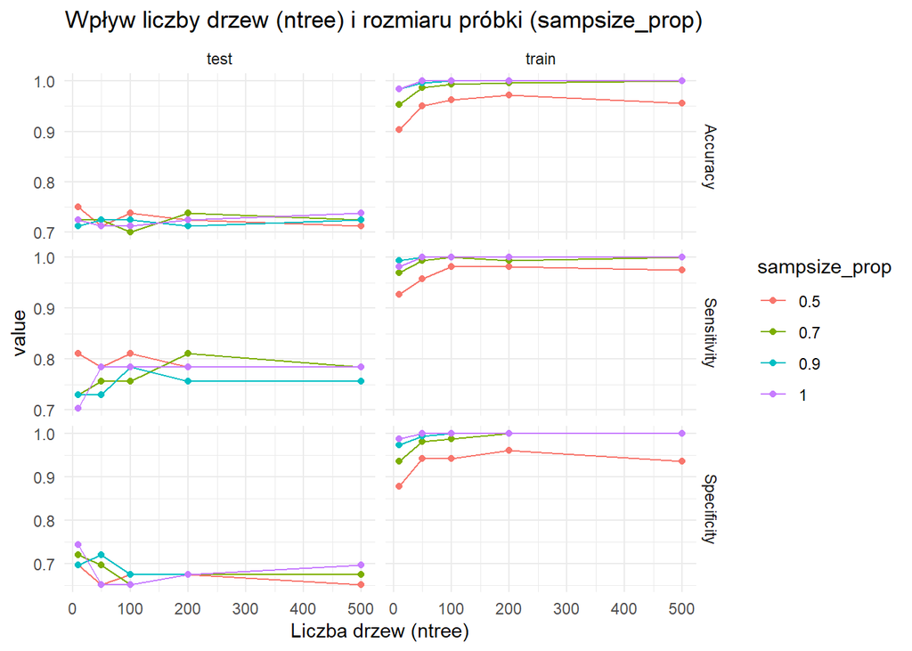

```r
results_long = results %>%
  pivot_longer(cols = starts_with(c("Accuracy", "Sensitivity", "Specificity")),
               names_to = c("metric", "set"),
               names_sep = "_",
               values_to = "value")

# Rysujemy osobno dla train/test (facet) i oddzielnie dla metric
ggplot(results_long, aes(x = ntree, y = value, color = as.factor(sampsize_prop))) +
  geom_line() + geom_point() +
  facet_grid(metric ~ set, scales = "free_y") +
  labs(title = "Wpływ liczby drzew (ntree) i rozmiaru próbki (sampsize_prop)",
       x = "Liczba drzew (ntree)",
       color = "sampsize_prop") +
  theme_minimal()
```

Model jest przeuczony, w szczególności dla większej liczby drzew. Widać dysproporcję w wynikach na zbiorze testowym. Największa czułość w okolicy 100 drzew

## Najlepszy model

```r
best_idx = which.max(results$Sensitivity_test + 1e-6 * results$Accuracy_test) #Głównie zależy nam na czułości
best_row = results[best_idx, ]
cat("Najlepsze parametry wg (Sensitivity_test, potem Accuracy_test):\n")
```

```
## Najlepsze parametry wg (Sensitivity_test, potem Accuracy_test):
```

```r
best_row
```

```
##          ntree sampsize_prop sampsize_n Accuracy_train Sensitivity_train
## Accuracy    10           0.5        160       0.903125         0.9263804
##          Specificity_train Accuracy_test Sensitivity_test Specificity_test
## Accuracy         0.8789809          0.75        0.8108108        0.6976744
```

Najlepszy model to model dla 10 drzew i 0,5 proporcję obserwacji ze zbioru uczącego. Osiąga on zdecydowanie słabsze wyniki na zbiorze testowym, jednak nadal są to poprawne wyniki (dokładność 75%, czułość 81% i specyficzność około 70%)

# Zadanie 4

```r
# Metryki dla najlepszego drzewa (z Zad. 2)

best_tree_pred <- predict(model2, newdata = testowy, type = "class")
best_tree_cm <- confusionMatrix(best_tree_pred, testowy$stroke, positive = "1")

# Metryki dla najlepszego modelu bagging (z Zad. 3)

best_bagging <- randomForest(
formula = stroke ~ .,
data = uczacy,
ntree = best_row$ntree,
mtry = p,
sampsize = floor(nrow(uczacy) * best_row$sampsize_prop),
replace = TRUE
)
best_bagging_pred <- predict(best_bagging, newdata = testowy, type = "response")
best_bagging_cm <- confusionMatrix(best_bagging_pred, testowy$stroke, positive = "1")

best_tree_cm
```

```
## Confusion Matrix and Statistics
##
##           Reference
## Prediction  0  1
##          0 29  8
##          1 14 29
##
##                Accuracy : 0.725
##                  95% CI : (0.6138, 0.819)
##     No Information Rate : 0.5375
##     P-Value [Acc > NIR] : 0.0004578
##
##                   Kappa : 0.4531
##
##  Mcnemar's Test P-Value : 0.2864220
##
##             Sensitivity : 0.7838
##             Specificity : 0.6744
##          Pos Pred Value : 0.6744
##          Neg Pred Value : 0.7838
##              Prevalence : 0.4625
##          Detection Rate : 0.3625
##    Detection Prevalence : 0.5375
##       Balanced Accuracy : 0.7291
##
##        'Positive' Class : 1
##
```

```r
best_bagging_cm
```

```
## Confusion Matrix and Statistics
##
##           Reference
## Prediction  0  1
##          0 29  7
##          1 14 30
##
##                Accuracy : 0.7375
##                  95% CI : (0.6271, 0.8296)
##     No Information Rate : 0.5375
##     P-Value [Acc > NIR] : 0.0001904
##
##                   Kappa : 0.4789
##
##  Mcnemar's Test P-Value : 0.1904303
##
##             Sensitivity : 0.8108
##             Specificity : 0.6744
##          Pos Pred Value : 0.6818
##          Neg Pred Value : 0.8056
##              Prevalence : 0.4625
##          Detection Rate : 0.3750
##    Detection Prevalence : 0.5500
##       Balanced Accuracy : 0.7426
##
##        'Positive' Class : 1
##
```

## Porównanie drzewa decyzyjnego i baggingu

Porównując uzyskane wyniki, można zauważyć, że metoda **bagging** poprawiła jakość predykcji względem pojedynczego drzewa decyzyjnego. Dokładność wzrosła z około **72,5%** do **73,7%**, a czułość z **78%** do **81%**. Oznacza to, że model lepiej wykrywa przypadki udaru, co ma duże znaczenie w analizie medycznej.

Zaletą baggingu jest **większa stabilność i mniejsze ryzyko przeuczenia**, ponieważ wynik powstaje na podstawie uśrednienia wielu drzew. Wadą jest natomiast **utrata interpretowalności** — trudno wskazać pojedyncze reguły decyzyjne, które stoją za predykcją.

Z kolei proste drzewo decyzyjne jest **łatwe w interpretacji** i pozwala zrozumieć, jakie czynniki wpływają na wynik, ale jest bardziej podatne na błędy losowe i przeuczenie.

**Podsumowując:** najlepsze wyniki osiąga bagging, natomiast pojedyncze drzewo warto stosować wtedy, gdy zależy nam na interpretacji i zrozumieniu decyzji modelu.